# Titanic Prediction with Bayes

Chris Mulvihill

June 2021

# The Approach

In the examples of analysis of this data set that I have seen, there is a pattern of the output being a logical true/false statement of whether someone had survived. This generally makes sense since this is using a well known data set that that the results can be checked against to see if the prediction was correct. However, this is often not the case. In my studies, I have found that it is better to include how certain we are of the results rather than simply including the true/false output.

Using Bayesian statistics within the model, it will be possible to predict the likelihood of a passenger surviving based on the probabilities found in the training data.

Using variations of the following formula for each variable in the data set, it will be possible to compute the base probabilities that can then be combined for each combination that a passenger fits into.

$$P\left(survived|female\right)=\frac{P\left(female|survived\right)*P\left(survived\right)}{P\left(female\right)}$$

For example, if a passenger if female with a first class ticket, we combine the probabilities for survival given that they are female with the probability that they have a first class ticket since each factor may contribute to their survival.

# Initial EDA

Importing the data:

```r
# loading the tidyverse package
library(tidyverse)

# reading in the training data
titanic.train <- read_csv("../data/train.csv")

# reading in the test data
titanic.test <- read_csv("../data/test.csv")
```

Checking that the data was read in correctly First 10 rows of titanic.train

```r
head(titanic.train, n=10)
```

```
## # A tibble: 10 x 12
##    PassengerId Survived Pclass Name   Sex     Age SibSp Parch Ticket  Fare Cabin
##          <dbl>    <dbl>  <dbl> <chr>  <chr> <dbl> <dbl> <dbl> <chr>  <dbl> <chr>
##  1           1        0      3 Braun~ male     22     1     0 A/5 2~  7.25 <NA>
##  2           2        1      1 Cumin~ fema~    38     1     0 PC 17~ 71.3  C85
##  3           3        1      3 Heikk~ fema~    26     0     0 STON/~  7.92 <NA>
##  4           4        1      1 Futre~ fema~    35     1     0 113803 53.1  C123
##  5           5        0      3 Allen~ male     35     0     0 373450  8.05 <NA>
##  6           6        0      3 Moran~ male     NA     0     0 330877  8.46 <NA>
##  7           7        0      1 McCar~ male     54     0     0 17463  51.9  E46
##  8           8        0      3 Palss~ male      2     3     1 349909 21.1  <NA>
##  9           9        1      3 Johns~ fema~    27     0     2 347742 11.1  <NA>
## 10          10        1      2 Nasse~ fema~    14     1     0 237736 30.1  <NA>
## # ... with 1 more variable: Embarked <chr>
```

First 10 rows of titanic.test

```r
head(titanic.test, n=10)
```

```
## # A tibble: 10 x 11
##    PassengerId Pclass Name   Sex     Age SibSp Parch Ticket  Fare Cabin Embarked
##          <dbl>  <dbl> <chr>  <chr> <dbl> <dbl> <dbl> <chr>  <dbl> <chr> <chr>
##  1         892      3 Kelly~ male   34.5     0     0 330911  7.83 <NA>  Q
##  2         893      3 Wilke~ fema~  47       1     0 363272  7    <NA>  S
##  3         894      2 Myles~ male   62       0     0 240276  9.69 <NA>  Q
##  4         895      3 Wirz,~ male   27       0     0 315154  8.66 <NA>  S
##  5         896      3 Hirvo~ fema~  22       1     1 31012~ 12.3  <NA>  S
##  6         897      3 Svens~ male   14       0     0 7538    9.22 <NA>  S
##  7         898      3 Conno~ fema~  30       0     0 330972  7.63 <NA>  Q
##  8         899      2 Caldw~ male   26       1     1 248738 29    <NA>  S
##  9         900      3 Abrah~ fema~  18       0     0 2657    7.23 <NA>  C
## 10         901      3 Davie~ male   21       2     0 A/4 4~ 24.2  <NA>  S
```

## combining the data sets for cleaning

### Step 1: make the columns match

- Check that the names are the same
- add a “survived” column to the test set

```r
train.names <- names(titanic.train)
test.names <- names(titanic.test)
setdiff(train.names, test.names)
```

```
## [1] "Survived"
```

```r
intersect(train.names, test.names)
```

```
##  [1] "PassengerId" "Pclass"      "Name"        "Sex"         "Age"
##  [6] "SibSp"       "Parch"       "Ticket"      "Fare"        "Cabin"
## [11] "Embarked"
```

The column names are the same with the exception of the “Survived” column that is missing from the test data.

```r
titanic.test$Survived <- NA
head(titanic.test)
```

```
## # A tibble: 6 x 12
##   PassengerId Pclass Name    Sex     Age SibSp Parch Ticket  Fare Cabin Embarked
##         <dbl>  <dbl> <chr>   <chr> <dbl> <dbl> <dbl> <chr>  <dbl> <chr> <chr>
## 1         892      3 Kelly,~ male   34.5     0     0 330911  7.83 <NA>  Q
## 2         893      3 Wilkes~ fema~  47       1     0 363272  7    <NA>  S
## 3         894      2 Myles,~ male   62       0     0 240276  9.69 <NA>  Q
## 4         895      3 Wirz, ~ male   27       0     0 315154  8.66 <NA>  S
## 5         896      3 Hirvon~ fema~  22       1     1 31012~ 12.3  <NA>  S
## 6         897      3 Svenss~ male   14       0     0 7538    9.22 <NA>  S
## # ... with 1 more variable: Survived <lgl>
```

### Step 2: Combine the data sets

using rbind to combine the data into a single set.

```r
titanic.full <- rbind(titanic.test, titanic.train)
nrow(titanic.full)
```

```
## [1] 1309
```

## Cleaning the Data

### Cleaning “Age”

Looking for missing data in the *Age* column

```r
table(is.na(titanic.full$Age))
```

```
##
## FALSE  TRUE
##  1046   263
```

There are 263 missing values in the Age data.

Writing a function to find the mode

```r
getMode <- function(x){
  keys <- na.omit(unique(x))
  keys[which.max(tabulate(match(x, keys)))]
}
```

Getting the mode of “Age”

```r
age.mode <- getMode(titanic.full$Age)
age.mode
```

```
## [1] 24
```

Replacing the missing age with the mode for age

```r
titanic.clean <- titanic.full %>%
  mutate(Age = ifelse(is.na(Age), age.mode, Age))
table(is.na(titanic.clean$Age))
```

```
##
## FALSE
##  1309
```

All NA values in “Age” have been replaced with the mode of “Age”.

### Cleaning The “Fare” data

Finding missing “Fare” values

```r
table(is.na(titanic.full$Fare))
```

```
##
## FALSE  TRUE
##  1308     1
```

Only 1 missing Fare

Finding the Mode of the Fare to replace the missing value

```r
fare.mode <- getMode(titanic.full$Fare)
fare.mode
```

```
## [1] 8.05
```

Replacing the missing Fare with the mode

```r
titanic.clean <- titanic.clean %>%
  mutate(Fare = ifelse(is.na(Fare), fare.mode, Fare))
table(is.na(titanic.clean$Fare))
```

```
##
## FALSE
##  1309
```

Fare is now clean.

### Cleaning Pclass data

```r
table(is.na(titanic.full$Pclass))
```

```
##
## FALSE
##  1309
```

No missing values in Pclass

### Cleaning Sex data

```r
table(is.na(titanic.full$Sex))
```

```
##
## FALSE
##  1309
```

No missing values in Sex

### Cleaning the Embarked data

```r
table(is.na(titanic.full$Embarked))
```

```
##
## FALSE  TRUE
##  1307     2
```

There are 2 missing values in Embarked.

Finding the most common value to replace the missing data with:

```r
table(titanic.full$Embarked)
```

```
##
##   C   Q   S
## 270 123 914
```

“S” is the most common value so I will replace the missing data with “S”.

```r
titanic.clean <- titanic.clean %>%
  mutate(Embarked = ifelse(is.na(Embarked), "S", Embarked))
table(titanic.clean$Embarked)
```

```
##
##   C   Q   S
## 270 123 916
```

The 2 missing values have been replaced with “S”.

### Cleaning the Cabin data

```r
titanic.full %>%
  filter(!is.na(Cabin)) %>%
  .$Cabin %>%
  head(n=50)
```

```
##  [1] "B45"             "E31"             "B57 B59 B63 B66" "B36"
##  [5] "A21"             "C78"             "D34"             "D19"
##  [9] "A9"              "D15"             "C31"             "C23 C25 C27"
## [13] "F G63"           "B61"             "B57 B59 B63 B66" "C53"
## [17] "C23 C25 C27"     "D43"             "C130"            "C132"
## [21] "C101"            "C55 C57"         "B71"             "C46"
## [25] "C116"            "F"               "A29"             "C55 C57"
## [29] "G6"              "C6"              "C28"             "C51"
## [33] "B57 B59 B63 B66" "E46"             "C54"             "C97"
## [37] "D22"             "B10"             "C116"            "F4"
## [41] "E45"             "E52"             "D30"             "B58 B60"
## [45] "E34"             "C62 C64"         "A11"             "B11"
## [49] "C80"             "F33"
```

The Cabin values all start with a letter which is likely associated with a section on the ship. The way modern airplane or theater tickets are laid out. If the letter is extracted from each cabin id and placed in a new “Cabin_Section” vector, it can be used to further classify passengers. *The theory that is that some cabins sections may have been closer to the life boats.

```r
titanic.clean <- titanic.clean %>%
  separate(Cabin, into = c("Cabin_Section", "Cabin_Number"), "\\d", extra = "merge")
table(titanic.clean[!is.na(titanic.clean$Cabin_Section), "Cabin_Section"])
```

```
##
##   A   B   C   D   E   F F E F G   G   T
##  22  65  94  46  41  14   3   4   5   1
```

```r
table(is.na(titanic.clean$Cabin_Section))
```

```
##
## FALSE  TRUE
##   295  1014
```

there are too many NAs to fill for this data to be accurate.

# Determining Initial Probabilites

```r
p_survived <- titanic.clean %>%
  filter(!is.na(Survived)) %>%
  pull(Survived) %>%
  mean()
p_survived
```

```
## [1] 0.3838384
```

## Probability of survival given sex:

$$P\left(survival\ |\ sex_{i}\right) = \frac{P\left(sex_{i}\ |\ survival\right)* P\left(survival\right)}{P\left(sex_{i}\right)}$$

```r
p_female <- mean(titanic.clean$Sex[1:891] == "female")
p_female
```

```
## [1] 0.369248
```

```r
p_survived <- titanic.clean %>%
  filter(!is.na(Survived)) %>%
  pull(Survived) %>%
  mean()
p_survived
```

```
## [1] 0.3838384
```

```r
p.female.survived <- titanic.clean %>% filter(Survived == 1) %>%
  .$Sex %>%
  table()
p.female.survived <- p.female.survived[[1]]/sum(p.female.survived)
p.female.survived
```

```
## [1] 0.6812865
```

```r
p.survived.female <- (p.female.survived * p_survived)/p_female
p.survived.female
```

```
## [1] 0.7082067
```

There is a 70.8% of a female surviving based the Bayesian probability.

```r
p.survived.male <- ((1 - p.female.survived) * p_survived) / (1 - p_female)
p.survived.male
```

```
## [1] 0.1939502
```

```r
survived_by_sex <- data.frame(
  sex = c("Female", "Male"),
  prob_survived = c(p.survived.female, p.survived.male),
  prob_sex = c(p_female, 1-p_female)
)
survived_by_sex
```

```
##      sex prob_survived prob_sex
## 1 Female     0.7082067 0.369248
## 2   Male     0.1939502 0.630752
```

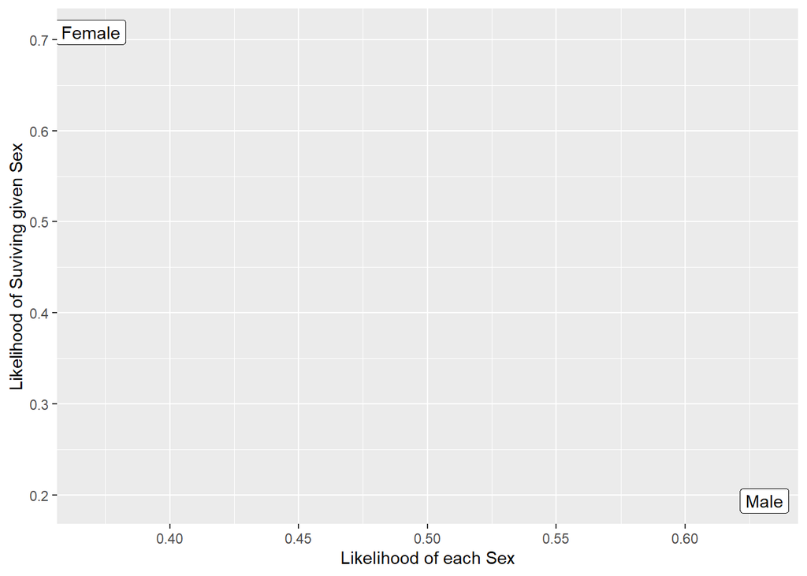

## Determining probabilities per class

```r
class.survived <- titanic.clean %>%
  filter(Survived == 1) %>%
  pull(Pclass) %>%
  table()
class.survived
```

```
## .
##   1   2   3
## 136  87 119
```

```r
class <- titanic.clean %>%
  filter(!is.na(Survived)) %>%
  pull(Pclass) %>%
  table()
class
```

```
## .
##   1   2   3
## 216 184 491
```

```r
p.class.first <- class[[1]]/sum(class)
p.class.second <- class[[2]]/sum(class)
p.class.third <- class[[3]]/sum(class)
```

```r
p.first.survived <- class.survived[[1]] / sum(class.survived)
p.first.survived
```

```
## [1] 0.3976608
```

The probability of being in first class given that a passenger survived is 39.76%

```r
p.second.survived <- class.survived[[2]] / sum(class.survived)
p.second.survived
```

```
## [1] 0.254386
```

The probability of being in second class given that a passenger survived is 25.43%

```r
p.third.survived <- class.survived[[3]] / sum(class.survived)
p.third.survived
```

```
## [1] 0.3479532
```

The probability of being in third class given that a passenger survived is 34.79%

### Finding the probablity of surviving in each class:

```r
p.survived.first <- (p.first.survived * p_survived)/p.class.first
p.survived.first
```

```
## [1] 0.6296296
```

```r
p.survived.second <- (p.second.survived * p_survived)/p.class.second
p.survived.second
```

```
## [1] 0.4728261
```

```r
p.survived.third <- (p.third.survived * p_survived)/p.class.third
p.survived.third
```

```
## [1] 0.2423625
```

```r
survived_by_class <- data.frame(Class = c("first", "second", "third"),
           survival_prob = c(p.survived.first, p.survived.second, p.survived.third),
           class_prob = c(p.class.first, p.class.second, p.class.third))
survived_by_class
```

```
##    Class survival_prob class_prob
## 1  first     0.6296296  0.2424242
## 2 second     0.4728261  0.2065095
## 3  third     0.2423625  0.5510662
```

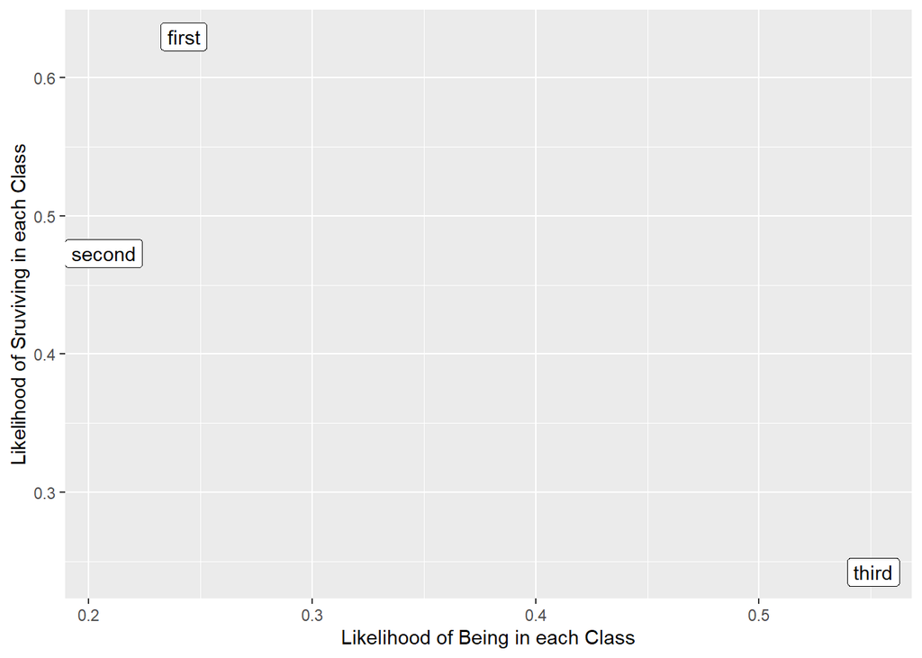

# Testing The Model So Far

building a function to compute survival based on sex and class

```r
class_prob <- function(x){
  if(x == 3){
    prob <- p.survived.third
  } else if(x == 2){
    prob <- p.survived.second
  } else if(x == 1){
    prob <- p.survived.first
  }
  return(prob)
}
sex_prob <- function(x){
  if(x == "female"){
    prob <- p.survived.female
  } else if(x == "male"){
    prob <- p.survived.male
  }
  return(prob)
}
```

```r
titanic.clean %>% mutate(
  class_prob = sapply(Pclass, class_prob),
  sex_prob = sapply(Sex, sex_prob),
  survived_prob = class_prob * sex_prob
) %>%
  select(Sex, sex_prob, Pclass, class_prob, Survived, survived_prob) %>%
  filter(!is.na(Survived)) %>%
  head(n=10)
```

```
## # A tibble: 10 x 6
##    Sex    sex_prob Pclass class_prob Survived survived_prob
##    <chr>     <dbl>  <dbl>      <dbl>    <dbl>         <dbl>
##  1 male      0.194      3      0.242        0        0.0470
##  2 female    0.708      1      0.630        1        0.446
##  3 female    0.708      3      0.242        1        0.172
##  4 female    0.708      1      0.630        1        0.446
##  5 male      0.194      3      0.242        0        0.0470
##  6 male      0.194      3      0.242        0        0.0470
##  7 male      0.194      1      0.630        0        0.122
##  8 male      0.194      3      0.242        0        0.0470
##  9 female    0.708      3      0.242        1        0.172
## 10 female    0.708      2      0.473        1        0.335
```